# Week 14, Part 1: Regression, Dependence and Standard Errors

PS 813 - Causal Inference

Anton Strezhnev

strezhnev@wisc.edu

University of Wisconsin-Madison

April 26, 2027

$$\require{cancel}$$

## Today

- Going back to **estimation** with **ordinary least squares** regression.
  - Estimand: $\mathbb{E}[Y|X]$
- What happens when we have **dependence** across units
  - Dependence due to cluster-based **sampling** from a target population
  - Dependence due to cluster-based **assignment** of treatment
- Various forms of “robust” standard errors
  - Conventional “heteroskedasticity” robust SEs
  - Cluster-robust standard errors
  - Spatial HAC
- When do these work? What sample sizes do I need for valid inference? How do I implement a bootstrap?

## Regression Review

- We observe an outcome $Y_i$ and a $K \times 1$ vector of predictors $X_i$ for each of $N$ units (one of which is a constant – the “intercept”)
  - We’ll stack these into the $N \times 1$ outcome vector $Y$ and the $N \times K$ design matrix $\mathbf{X}$
- Consider the **ordinary least squares** estimator

  $$\hat{\beta} = \bigg(\frac{1}{N}\sum_{i=1}^N X_iX_i^\prime\bigg)^{-1}\bigg(\frac{1}{N}\sum_{i=1}^N X_iY_i\bigg) = (\mathbf{X}^\prime\mathbf{X})^{-1}\mathbf{X}^\prime Y$$

## Regression Review

- When is OLS consistent for the true conditional expectation function $\mathbb{E}[Y_i | X_i]$?
  1. **Linear** CEF

  $$Y_i = X_i^\prime \beta + \epsilon_i = \beta_1 X_{i1} + \beta_2 X_{i2} + \dotsc + \beta_K X_{iK} + \epsilon_i$$

  2. Zero Conditional Mean Error

  $$\mathbb{E}[\epsilon \mid \mathbf{X}] = 0$$

  3. No perfect collinearity

## Aside: Leverage/Hat values

- The **fitted values** from OLS can be written as a linear projection of $Y$ onto the column space of $\mathbf{X}$

  $$\hat{Y} = \mathbf{X}\hat{\beta} = \mathbf{X}(\mathbf{X}^\prime\mathbf{X})^{-1}\mathbf{X}^\prime Y = \mathbf{H}Y$$
- $\mathbf{H} = \mathbf{X}(\mathbf{X}^\prime\mathbf{X})^{-1}\mathbf{X}^\prime$ is the **projection matrix** or **hat matrix** (“hat” because it puts the hat on $Y$).
- $\mathbf{H}$ is symmetric
- $\mathbf{H}$ is idempotent ($\mathbf{H}\mathbf{H} = \mathbf{H}$).

## Aside: Leverage/Hat values

- One way to think about the values of $\mathbf{H}$ is they define the **weights** that generate $\hat{Y}$ from $Y$

  $$\hat{Y}_i = \sum_{j=1}^N h_{ij} Y_j$$
- Note that these weights are **not convex**!
- The **diagonal** elements $h_{ii}$ of the matrix are referred to as the **leverage** of each observation
  - Captures how much the prediction for unit $i$ will change in response to a change in the **observation** for $i$
- “High leverage” observations are those that are **extreme** in the covariate space.

## Regression Standard Errors

- We have an estimator, $\hat{\beta}$. We want to estimate its **variance**. Two questions:
  - What is the **actual** variance? $Var(\hat{\beta})$
  - Can we come up with a good estimator of it? $\widehat{Var}(\hat{\beta})$
- Let’s first derive the variance. Plugging $Y = \mathbf{X}\beta + \epsilon$ into the OLS formula:

  $$\hat{\beta} - \beta = (\mathbf{X}^\prime\mathbf{X})^{-1}\mathbf{X}^\prime\epsilon$$
- Taking the conditional variance:

  $$\text{Var}(\hat{\beta} \mid \mathbf{X}) = (\mathbf{X}^\prime\mathbf{X})^{-1}\mathbf{X}^\prime \, \mathbb{E}[\epsilon\epsilon^\prime \mid \mathbf{X}] \, \mathbf{X}(\mathbf{X}^\prime\mathbf{X})^{-1}$$
- Define $\mathbf{\Sigma} \equiv \mathbb{E}[\epsilon\epsilon^\prime \mid \mathbf{X}]$ - the $N \times N$ variance-covariance matrix of the errors:

  $$\text{Var}(\hat{\beta} \mid \mathbf{X}) = (\mathbf{X}^\prime\mathbf{X})^{-1} \, \mathbf{X}^\prime \mathbf{\Sigma} \mathbf{X} \, (\mathbf{X}^\prime\mathbf{X})^{-1}$$

## Regression Standard Errors

- Equivalently:

  $$\text{Var}(\hat{\beta} \mid \mathbf{X}) = \frac{1}{N}\bigg(\frac{1}{N}\sum_{i=1}^N X_iX_i^\prime\bigg)^{-1}\bigg(\frac{1}{N}\sum_{i=1}^N \sum_{j=1}^N \sigma_{ij} X_iX_j^\prime\bigg)\bigg(\frac{1}{N}\sum_{i=1}^N X_iX_i^\prime\bigg)^{-1}$$

  where $\sigma_{ij} = \text{Cov}(\epsilon_i, \epsilon_j \mid \mathbf{X})$ is the $(i, j)$ entry of $\mathbf{\Sigma}$.
- Our various approaches to estimation will make different assumptions on $\mathbf{\Sigma}$ to facilitate estimation.

## Classical Standard Errors

- The **classical** OLS variance estimator imposes an assumption of **spherical errors**

  $$\text{Var}(\epsilon \mid \mathbf{X}) = \sigma^2\mathbf{I}$$
- Two underlying assumptions:
  - **Homoskedasticity**: $\text{Var}(\epsilon_i \mid X_i) = \sigma^2$ for all $i$
  - **Zero error covariance**: $\text{Cov}(\epsilon_i, \epsilon_j \mid \mathbf{X}) = 0$ for $i \neq j$
- Under spherical errors, the sandwich form simplifies as $\mathbf{\Sigma} = \sigma^2\mathbf{I}$:

  $$\text{Var}(\hat{\beta} \mid \mathbf{X}) = (\mathbf{X}^\prime\mathbf{X})^{-1} (\mathbf{X}^\prime \sigma^2 \mathbf{I} \mathbf{X}) (\mathbf{X}^\prime\mathbf{X})^{-1} = \sigma^2 (\mathbf{X}^\prime\mathbf{X})^{-1}$$

## Classical Standard Errors

- An unbiased estimator for $\sigma^2$ uses the residuals with a degrees-of-freedom correction

  $$\hat{\sigma}^2 = \frac{1}{N - K} \sum_{i=1}^N \hat{e}_i^2$$
- Yielding the classical variance estimator

  $$\widehat{\text{Var}(\hat{\beta})} = \hat{\sigma}^2 (\mathbf{X}^\prime\mathbf{X})^{-1}$$

## Heteroskedasticity-robust SEs

- Our first relaxation is to allow $\text{Var}(\epsilon_i \mid X_i) = \sigma_i^2$ to vary across $i$
  - Still assume zero covariance **across** observations.
  - The variance-covariance matrix of the errors is a diagonal matrix $\mathbf{\Sigma} = \text{diag}(\sigma_1^2, \dotsc, \sigma_N^2)$.
- A consistent estimator of $Var(\hat{\beta})$ replaces $\sigma_i^2$ with the squared OLS residual $\hat{e}_i^2$

  $$\widehat{\text{Var}(\hat{\beta})} = (\mathbf{X}^\prime\mathbf{X})^{-1} \bigg(\sum_{i=1}^N \hat{e}_i^2 X_i X_i^\prime\bigg) (\mathbf{X}^\prime\mathbf{X})^{-1}$$
- This is the **Eicker-Huber-White** **heteroskedasticity-consistent** variance estimator

## Heteroskedasticity-robust SEs

- HC-robust SEs are **biased** in finite samples.
  - A number of corrections have been proposed which change how the $\sigma_i^2$ are imputed
  - These estimators tend to perform better in smaller samples
- **HC0**: $\hat{e}_i^2$ - the original estimator
- **HC1**: $\frac{N}{N - K}\hat{e}_i^2$ - a constant re-scaling by the degrees of freedom
- **HC2**: $\frac{\hat{e}_i^2}{1 - h_{ii}}$ - scale the residuals by the leverage
- **HC3**: $\frac{\hat{e}_i^2}{(1 - h_{ii})^2}$ - use the ``jacknife” residual

## Cluster-robust SEs

- Now let’s relax the assumption that $Cov(\epsilon_i, \epsilon_j | \mathbf{X}) = 0$ for $i \neq j$
  - A common structure of dependence is that errors are correlated **within groups** but independent **across groups**
- Index observations by cluster $g = 1, \dotsc, G$ and order the observations by cluster.
  - Let $X_g$ be the $N_g \times K$ design matrix and $\hat{e}_g$ the residual vector for cluster $g$.
- We assume $Cov(\epsilon_i, \epsilon_j | \mathbf{X}) = 0$ if $i$ and $j$ **do not** share a cluster.
- This makes $\mathbf{\Sigma}$ **block-diagonal** - $\sigma_{ij} = 0$ for $i, j$ in different clusters.
  - The “meat” of the sandwich becomes a sum over clusters:

  $$\text{Var}(\hat{\beta} \mid \mathbf{X}) = (\mathbf{X}^\prime\mathbf{X})^{-1} \bigg(\sum_{g=1}^G X_g^\prime \mathbf{\Sigma}_g X_g\bigg)(\mathbf{X}^\prime\mathbf{X})^{-1}$$

  where $\mathbf{\Sigma}_g = \mathbb{E}[\epsilon_g \epsilon_g^\prime \mid \mathbf{X}]$ is the $N_g \times N_g$ within-cluster block of $\mathbf{\Sigma}$.

## Cluster-robust SEs

- The **Liang-Zeger (1986)** cluster-robust estimator plugs in residuals at the cluster level

  $$\widehat{\text{Var}(\hat{\beta})} = (\mathbf{X}^\prime\mathbf{X})^{-1} \bigg(\sum_{g=1}^G X_g^\prime \hat{e}_g \hat{e}_g^\prime X_g\bigg) (\mathbf{X}^\prime\mathbf{X})^{-1}$$
- Arbitrary correlation structure **within** each cluster is allowed, but we restrict correlation **across** cluster
  - e.g. in many DiD/TWFE regression settings, we assume independence **across** unit but allow for arbitrary correlation over time.

## Cluster-robust SEs

- Crucially, now the consistency results for cluster-robust standard errors depend on $G$ going to infinity, not $N$
  - With a few clusters (less than $30$-ish), the conventional Liang-Zeger estimator will tend to **under-cover**
- Small sample corrections (cluster-level analogues of HC1/HC2):
  - **CR1** - multiply CR0 by $\frac{G}{G-1} \cdot \frac{N-1}{N-K}$ - a degrees-of-freedom rescaling at the cluster level
  - **CR2** (Bell-McCaffrey 2002): replace $\hat{e}_g \hat{e}_g^\prime$ with $\mathbf{A}_g \hat{e}_g \hat{e}_g^\prime \mathbf{A}_g^\prime$, where $\mathbf{A}_g = (\mathbf{I}_{N_g} - \mathbf{H}_{gg})^{-1/2}$ uses the within-cluster block $\mathbf{H}_{gg}$ of the hat matrix

## Simulation evidence: Setup

- $G$ clusters with $n_g = 10$ units each. Treatment $X_g$ assigned at the **cluster level** (half of clusters treated).
- Errors decompose into a cluster shock and an idiosyncratic shock

  $$\epsilon_{ig} = \alpha_g + u_{ig}, \quad \alpha_g \sim \mathcal{N}(0, \sigma_\alpha^2), \quad u_{ig} \sim \mathcal{N}(0, \sigma_u^2)$$

  with $\sigma_\alpha^2 + \sigma_u^2 = 1$, so the **intra-class correlation** is $\rho = \sigma_\alpha^2$.
- Outcome model with **no treatment effect**:

  $$Y_{ig} = \beta_0 + \epsilon_{ig}$$

## Simulation: Varying ICC

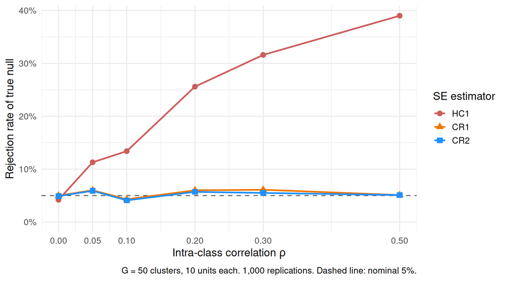

- HC1 **over-rejects severely** as soon as $\rho > 0$. CR1 and CR2 hold size at $G = 50$ across all ICC levels.

## Simulation: Varying number of clusters

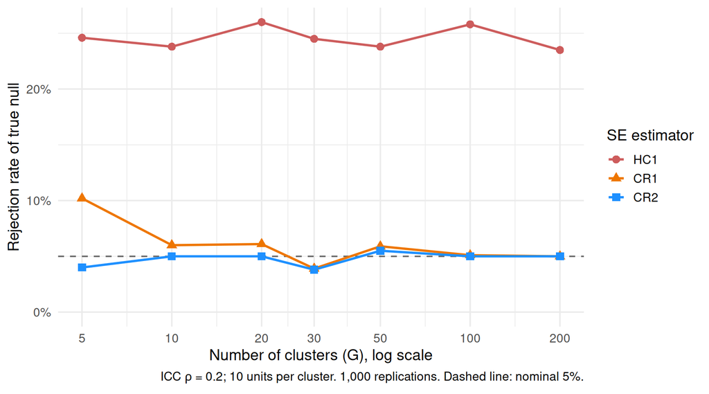

- HC1 over-rejects everywhere. CR1 over-rejects badly with few clusters; CR2 is much better-behaved but still imperfect at $G = 5$.

## Bootstrap methods

- We can extend the bootstrap beyond the conventional “pairs” bootstrap to deal with clustered covariance structure
  - **Block/cluster bootstrap**: resample **whole clusters** with replacement, keeping all units within a sampled cluster.
- We can also implement bootstrap procedures that don’t rely on **resampling** units entirely
  - **Fractional weighted** bootstrap: Randomly assign each unit a **weight** drawn from a uniform Dirichlet distribution multiplied by $n$ - run the weighted regression.
  - **Wild bootstrap** (Wu 1986; Mammen 1993): hold $X_i$ fixed, perturb the residuals by random sign-flips

    $$Y_i^{(b)} = X_i^\prime\hat{\beta} + \omega_i^{(b)} \hat{e}_i, \quad \omega_i^{(b)} \in \{-1, +1\}$$
  - **Wild cluster bootstrap** (Cameron, Gelbach, Miller 2008): same idea, but flip the sign of the entire cluster’s residuals together. Works well in small $G$ cases.

## Spatial autocorrelation

- Errors can also be correlated in **space**: observations on neighboring regions are exposed to common shocks.
- Cluster-robust SEs require a **partition** of the units but spatial dependence often does not have clear boundaries
- **Conley (1999) “spatial HAC”**
  - For estimating the “meat”, use the **cross-product** of the residuals weighted by the distance between the two observations.

    $$\widehat{\mathbf{X}^\prime \mathbf{\Sigma} \mathbf{X}} = \sum_{i=1}^N \sum_{j=1}^N w(d_{ij}, d^*) \hat{e}_i \hat{e}_j X_i X_j^\prime$$

  where $d_{ij}$ is the distance between $i$ and $j$ and $w(\cdot)$ is a kernel that goes to zero past cutoff distance $d^*$.
- The bandwidth $d^*$ is a researcher choice.

## Spatial simulation: Setup

- $25 \times 25$ regular grid of points indexed by location ($N = 625$). $d_{ij}$ = Euclidean distance between locations $i$ and $j$.
- Draw treatment from a **gaussian random field** $x = (x_1, \dotsc, x_N)^\prime$

  $$x \sim \mathcal{N}(0, \, \mathbf{\Sigma}_\rho), \qquad [\mathbf{\Sigma}_\rho]_{ij} = \exp(-d_{ij} / \rho)$$
- Draw errors independently from the same field (spatially correlated)
  - Both $X$ and $\epsilon$ inherit the same spatial structure
- Outcome: $Y_i = \beta_0 + \beta_1 X_i + \epsilon_i$ with $\beta_1 = 0$.

## Visualizing spatial dependence

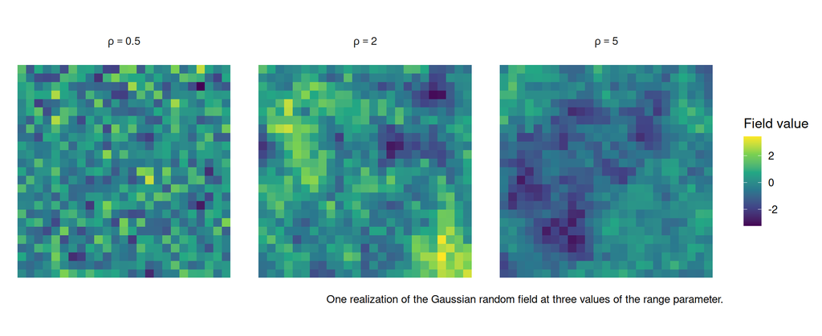

- Small $\rho$ looks like noise; large $\rho$ produces large coherent “patches”. Both $X_i$ and $\epsilon_i$ are independent realizations of this latent field at the same $\rho$.

## Spatial simulation: HC1 vs Conley

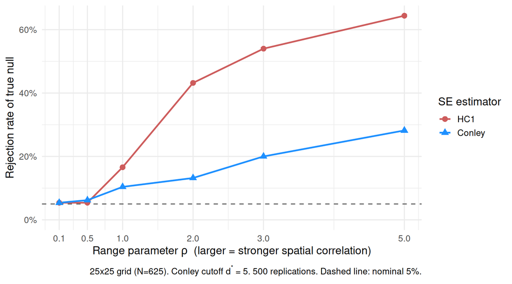

- HC1 over-rejects as $\rho$ grows. Conley does better but as the “range” of dependence gets large $\rho$, we also overreject!

## Design-based approaches

- We’ve focused on thinking about dependence from the standpoint of **model-based** inference
  - Clustered SEs are valid under **unobserved** cluster-level shocks **uncorrelated** with the regressors.
- But when are these estimators justified under **design-based** grounds?
- **Descriptive inference**
  - Clustering reflects the structure of **sampling** (e.g. sampling **villages** then **individuals**)
- **Causal inference** - Abadie, Athey, Imbens, Wooldridge (2020; 2023)
  - Can avoid clustering if treatment assignment is independent (e.g. complete randomization) **and** we’re targeting the SATE.
  - If there is clustering in either the treatment or the sampling scheme, then ignoring clustering will tend to under-cover.
- Xu and Wooldridge (2022) extend the design-based approach to spatial SEs

## Conclusion

- What standard errors should you use when you fit a linear regression?
- **Classical SEs** - Basically never
- **Heteroskedasticity-robust SEs** - Genuine i.i.d. sampling/treatment assignment
- **Cluster-robust SEs** - i.i.d. sampling/treatment assignment **by cluster**
  - Can just do the analysis at the **cluster level** as an alternative.
- **Dyadic/Multi-way SEs** (Aronow, Samii, and Assenova 2015; Cameron, Gelbach and Miller (2011))
  - Dependence between units that **share** a member (e.g. dyads)
- **Spatial SEs** - Dependence is **smooth** in some underlying space.
  - Need pretty **rapid** decay otherwise you’re functionally in an $N=1$ setting!
- Be **wary** of finite sample problems!
  - **Angrist and Pischke (2009)**: Rule of 42

## Next Lecture

- Come with questions!
  - We have lots of time for review!
- Concluding topic - **interference** in treatment assignment
  - How does the estimand change when there is arbitrary (unknown) interference?
  - Are there designs that facilitate estimation under known interference?
  - A common design with **interference**: the “shift-share” design.